# R Notebook

#### 0.0.0.1 **To: Professor Green**

#### 0.0.0.2 **From: Ralitza Mondal**

#### 0.0.0.3 **Date: 10/02/2019**

#### 0.0.0.4 **RE: OJ data Analysis**

```r
# Clear environment of variables and functions
rm(list = ls(all = TRUE))

# Clear environmet of packages
if(is.null(sessionInfo()$otherPkgs) == FALSE)lapply(paste("package:", names(sessionInfo()$otherPkgs), sep=""), detach, character.only = TRUE, unload = TRUE)
```

```r
# Load librarys
library(tidyverse)
```

```r
library(ggplot2)
library(gridExtra)
library(scales) # to get $ and , on axis in graph
```

# 1 Load and transform data

```r
# Load and prepare data
oj<-read.csv("OJ_Data.csv")
oj$STORE<-as.factor(oj$STORE)
oj$SpecialCH<-as.factor(oj$SpecialCH)
oj$SpecialMM<-as.factor(oj$SpecialMM)
```

# 2 Base EDA Step 1: Uni-variate non-graphical EDA

```r
head(oj,10)
```

```
##    Id Purchase PriceCH PriceMM DiscCH DiscMM SpecialCH SpecialMM STORE
## 1   1       CH    1.75    1.99   0.00    0.0         0         0     1
## 2   2       CH    1.75    1.99   0.00    0.3         0         1     1
## 3   3       CH    1.86    2.09   0.17    0.0         0         0     1
## 4   4       MM    1.69    1.69   0.00    0.0         0         0     1
## 5   5       CH    1.69    1.69   0.00    0.0         0         0     0
## 6   6       CH    1.69    1.99   0.00    0.0         0         1     0
## 7   7       CH    1.69    1.99   0.00    0.4         1         1     0
## 8   8       CH    1.75    1.99   0.00    0.4         1         0     0
## 9   9       CH    1.75    1.99   0.00    0.4         0         0     0
## 10 10       CH    1.75    1.99   0.00    0.4         0         0     0
```

```r
summary(oj)
```

```
##        Id         Purchase    PriceCH         PriceMM
##  Min.   :   1.0   CH:653   Min.   :1.690   Min.   :1.690
##  1st Qu.: 268.2   MM:417   1st Qu.:1.790   1st Qu.:1.990
##  Median : 535.5            Median :1.860   Median :2.090
##  Mean   : 535.5            Mean   :1.867   Mean   :2.085
##  3rd Qu.: 802.8            3rd Qu.:1.990   3rd Qu.:2.180
##  Max.   :1070.0            Max.   :2.090   Max.   :2.290
##      DiscCH            DiscMM       SpecialCH SpecialMM STORE
##  Min.   :0.00000   Min.   :0.0000   0:912     0:897     0:356
##  1st Qu.:0.00000   1st Qu.:0.0000   1:158     1:173     1:157
##  Median :0.00000   Median :0.0000                       2:222
##  Mean   :0.05186   Mean   :0.1234                       3:196
##  3rd Qu.:0.00000   3rd Qu.:0.2300                       4:139
##  Max.   :0.50000   Max.   :0.8000
```

```r
str(oj)
```

```
## 'data.frame':    1070 obs. of  9 variables:
##  $ Id       : int  1 2 3 4 5 6 7 8 9 10 ...
##  $ Purchase : Factor w/ 2 levels "CH","MM": 1 1 1 2 1 1 1 1 1 1 ...
##  $ PriceCH  : num  1.75 1.75 1.86 1.69 1.69 1.69 1.69 1.75 1.75 1.75 ...
##  $ PriceMM  : num  1.99 1.99 2.09 1.69 1.69 1.99 1.99 1.99 1.99 1.99 ...
##  $ DiscCH   : num  0 0 0.17 0 0 0 0 0 0 0 ...
##  $ DiscMM   : num  0 0.3 0 0 0 0 0.4 0.4 0.4 0.4 ...
##  $ SpecialCH: Factor w/ 2 levels "0","1": 1 1 1 1 1 1 2 2 1 1 ...
##  $ SpecialMM: Factor w/ 2 levels "0","1": 1 2 1 1 1 2 2 1 1 1 ...
##  $ STORE    : Factor w/ 5 levels "0","1","2","3",..: 2 2 2 2 1 1 1 1 1 1 ...
```

```r
table(oj$Purchase)
```

```
##
##  CH  MM
## 653 417
```

Answer ii: CH sells the most with 653

```r
table(oj$Purchase,oj$SpecialCH,oj$SpecialMM)
```

```
## , ,  = 0
##
##
##        0   1
##   CH 464 117
##   MM 279  37
##
## , ,  = 1
##
##
##        0   1
##   CH  68   4
##   MM 101   0
```

When there is no special on either CM or MM, people still preferred CH over MM When there is special on both CM or MM, people still preferred CH over MM

```r
table(oj$STORE)
```

```
##
##   0   1   2   3   4
## 356 157 222 196 139
```

Answer iii: Store 0 sells the most with 356 purchases

Answer iv: New variables: I would like to include new variables like population around the area for each of the stores, maybe there is lack of spread of information for the discounts on MM because of sparse population I would also like to include the age groups of the area I would also like to include average income to see if people are not sensitive to discounts on MM because of their wealth

## 2.1 Potential Questions/Comments to look into

Answer v: Comments: Store 0 is probably located in a dense populated area where information spreads quicker. But we need more data on the above variables mentioned to see people’s preference of CH over MM at various discount levels

# 3 Base EDA Step 2: Uni-variate graphical EDA

We are going to examine each variable individually

## 3.1 PriceCH

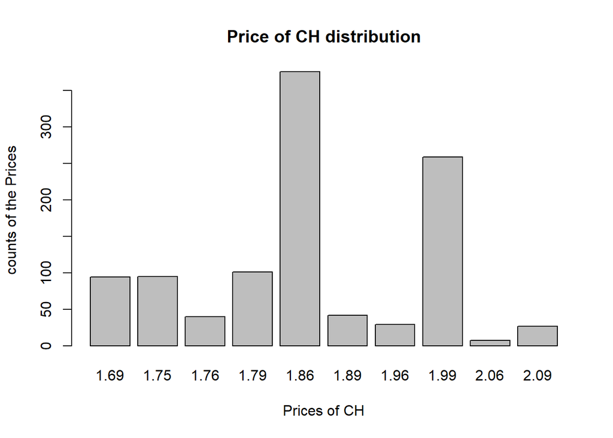

```r
counts<-table(oj$PriceCH)
barplot(counts,main="Price of CH distribution",
        xlab="Prices of CH", ylab="counts of the Prices")
```

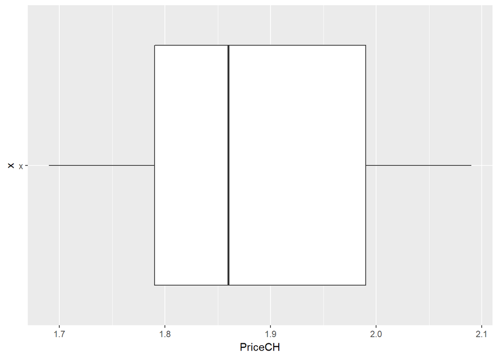

```r
ggplot(data = oj, mapping = aes(x = "x")) +
    geom_boxplot(mapping = aes(y = PriceCH)) +
    coord_flip() # use to have same x-axis on both graphs
```

+ Confirms there is a positively skewed distribution

```
- will use median rather than mean
```

## 3.2 PriceMM

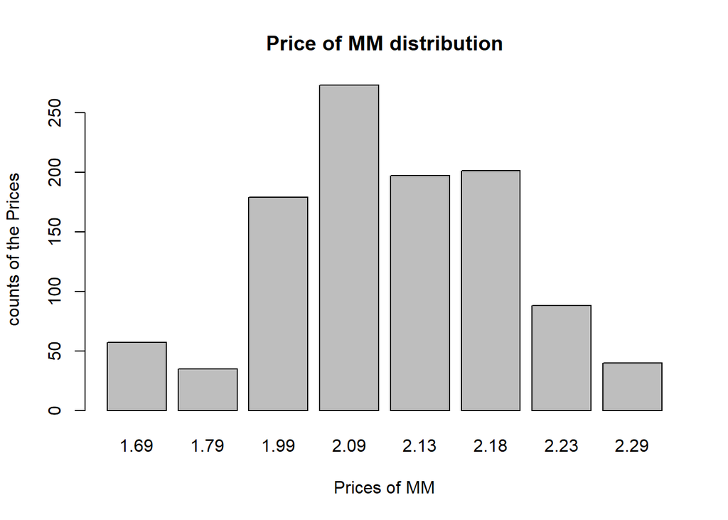

```r
counts<-table(oj$PriceMM)
barplot(counts,main="Price of MM distribution",
        xlab="Prices of MM", ylab="counts of the Prices")
```

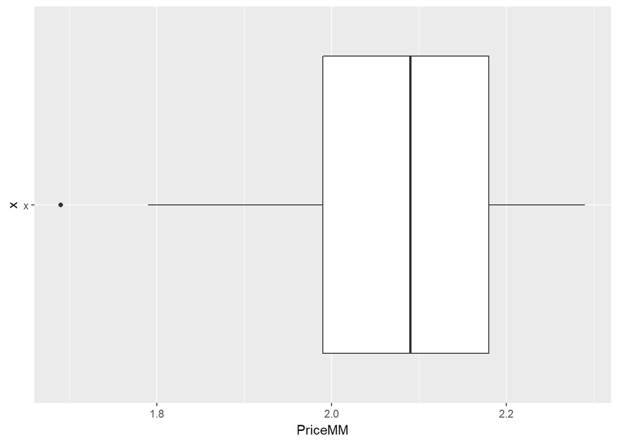

```r
ggplot(data = oj, mapping = aes(x = "x")) +
    geom_boxplot(mapping = aes(y = PriceMM)) +
    coord_flip() # use to have same x-axis on both graphs
```

+ Confirms there is no skewed distribution

```
- will use mean rather than median
-there is an outlier price that is $1.69 and there are around 60 of those.
```

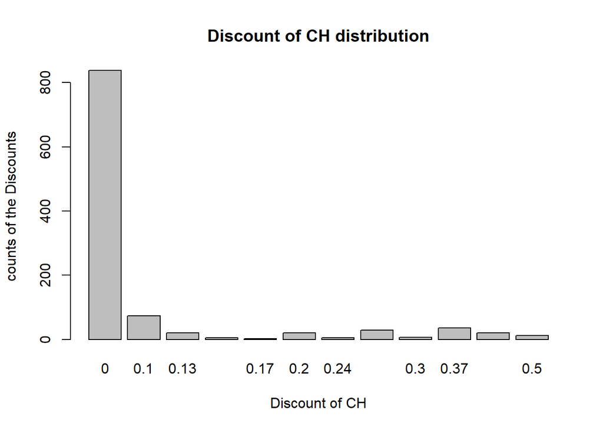

```r
counts<-table(oj$DiscCH)
barplot(counts,main="Discount of CH distribution",
        xlab="Discount of CH", ylab="counts of the Discounts")
```

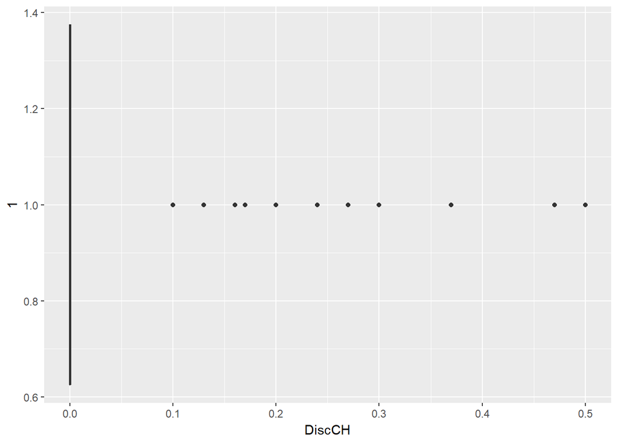

```r
ggplot(data = oj, mapping = aes(x = 1)) +
    geom_boxplot(mapping = aes(y = DiscCH)) +
    coord_flip() # use to have same x-axis on both graphs
```

We can see that in most of the cases, there is no discount for CH and so the box plot gives us outliers of al the discounts that are above 0

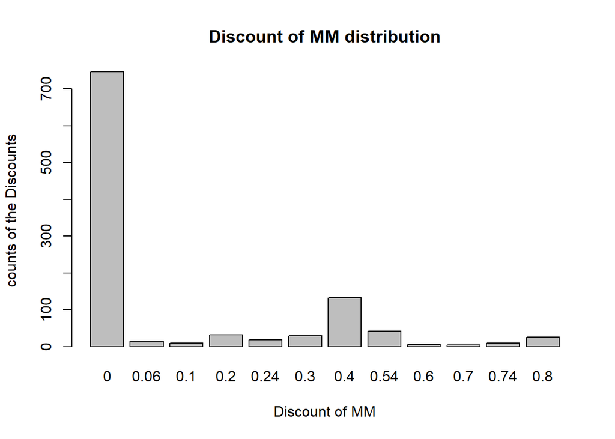

```r
counts<-table(oj$DiscMM)
barplot(counts,main="Discount of MM distribution",
        xlab="Discount of MM", ylab="counts of the Discounts")
```

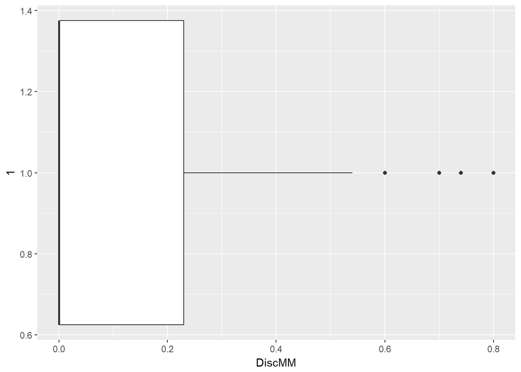

```r
ggplot(data = oj, mapping = aes(x = 1)) +
    geom_boxplot(mapping = aes(y = DiscMM)) +
    coord_flip() # use to have same x-axis on both graphs
```

We can see that the data is skewed and bi-modal. + Confirms there is positively skewed distribution

```
- will use median rather than mean
-there is an outlier price that are $.6,$.7,$.74,$.8
```

## 3.3 Categorical/Factor variables:

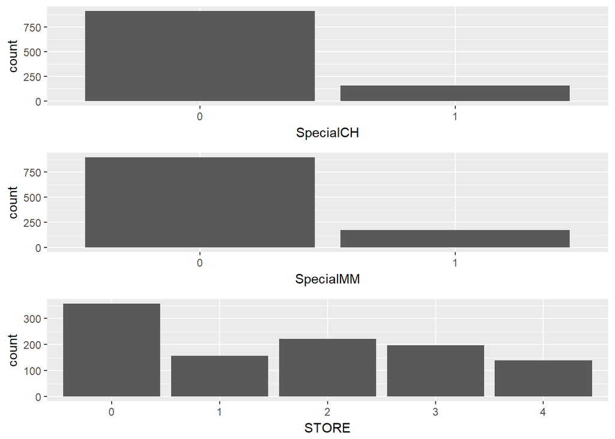

```r
grid.arrange(

# Special CH
ggplot(data = oj, mapping = aes(x = SpecialCH)) +
  geom_bar(),

# Special MM
ggplot(data = oj, mapping = aes(x = SpecialMM)) +
  geom_bar(),

# Store
ggplot(data = oj, mapping = aes(x = STORE)) +
  geom_bar(),

ncol = 1 )
```

- Mostly there is no specials purchased for both CH and MM
- Store 0 made the most purchases, followed by Store 2. The last three were:Store 3,Store 1 and then Store 4 respectively.

# 4 Creating professional quality visual

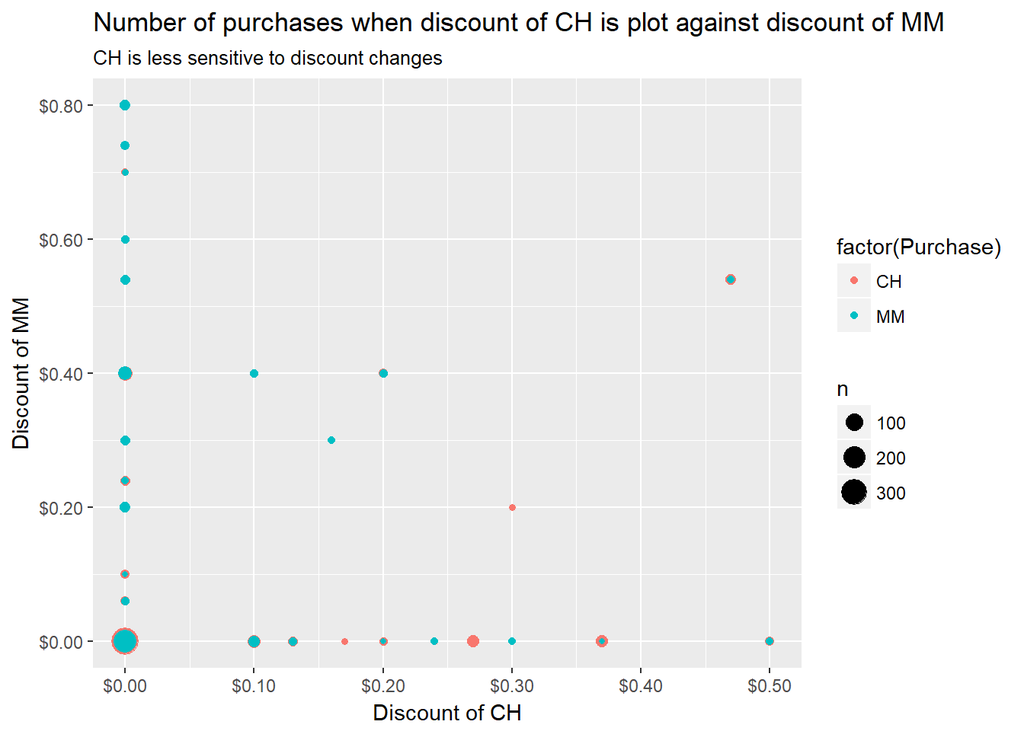

```r
Dis_Pur<-ggplot(oj,aes(x=DiscCH,y=DiscMM))+
  geom_count(aes(colour=factor(Purchase)))+
  ggtitle("Number of purchases when discount of CH is plot against discount of MM",
          sub = "CH is less sensitive to discount changes") +
  labs(x = "Discount of CH", y = "Discount of MM") +
  scale_y_continuous(labels = dollar)+
  scale_x_continuous(labels = dollar)# add dollar sign and comma in axis label from scales package

Dis_Pur
```

At no dicount level people generally prefer CH over MM Some instances we see people are also insensitive to the discount for MM, they still prefer CH even when there is a no discount for CH There is also an instance when CH has a less discounted price than MM and people still prefer CH over MM

# 5 Save graphs for use in other documents

```r
ggsave(filename = "Discount_Purchases.png", plot = Dis_Pur)
```